# Landscape Metrics in the Brasilian Cerrado remnants:

challenges and opportunities to conservation in the João Leite watershed, Goiânia Metropolitan Region

Izaias de Souza Silva[^1]

01-02-2024

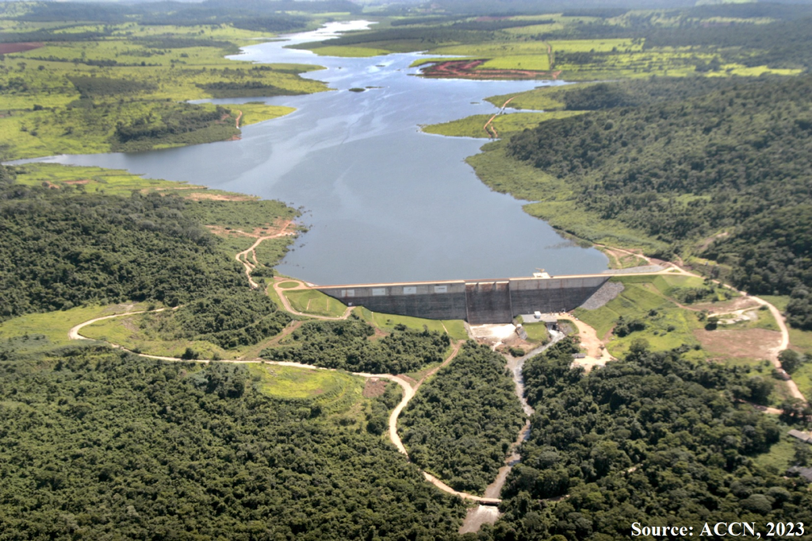

**1. Introduction**

The Brazilian Cerrado remnants are one of the critical points for its conservation (MYERS et al., 2000). The total or partial disappearance of the continuous and natural landscapes of the Brazilian Cerrado is gradually affecting its biodiversity and important ecosystem services, such as the regulation of the carbon balance and the availability of water (SANTOS et al., 2021). The Cerrado remnants play a crucial role in providing ecosystem services, such as regulating the climate, reducing surface runoff, helping to control soil erosion, protecting and contributing to the balance of aquatic ecosystems, among others (COSTA, 2015).

In its Nationally Determined Contribution (NDC) to the United Nations Framework Convention on Climate Change (UNFCCC), the Brazil not only emphasized its commitment to achieving zero deforestation by the year 2030, but also pledged to offset Greenhouse gas (GHG) emissions from suppression and changes in natural vegetation cover by restoring and conserving its standing forests (BRASIL, 2016). Despite this, the Cerrado’s continuous landscapes of natural vegetation cover continue to be intricately fragmented and limited to fragments that are, for the most part, not only isolated from each other, but also pressured by the anthropogenic activities that take place around them (MOTA JUNIOR et al., 2021; CHAVES, 2023). Assessing the environmental quality of these Cerrado remnants is therefore vital to understanding their current condition and providing support for their conservation (LONGO et al., 2024).

**1. Landscape Metrics**

This section presents some of the landscape metrics for Cerrado remnants in the João Leite watershed and in the partially located municipalitys. More details can be found in: https://www.fragstats.org/.

**CLASS AREA (CA):** This metric shows the total area of the thematic class at the landscape scale of a given spatial section. As such, it represents the sum of all the fragments/ patches of the respective thematic class.

**Ex.:** how much (%) of the landscape of each municipality partially located in the João Leite watershed are Cerrado remnants?

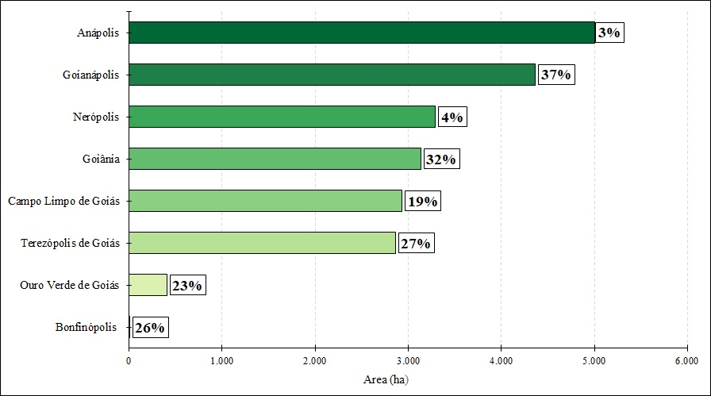

**NUMBER OF PATCHES (NumP):** This metric shows the total number of fragments/patches of the tamatic class at the landscape scale of a given spatial area.

**Ex.:** considering a semi-detailed mapping of Cerrado remnants in the João Leite watershed, which municipality partially located in the respective watershed has the largest number of fragments?

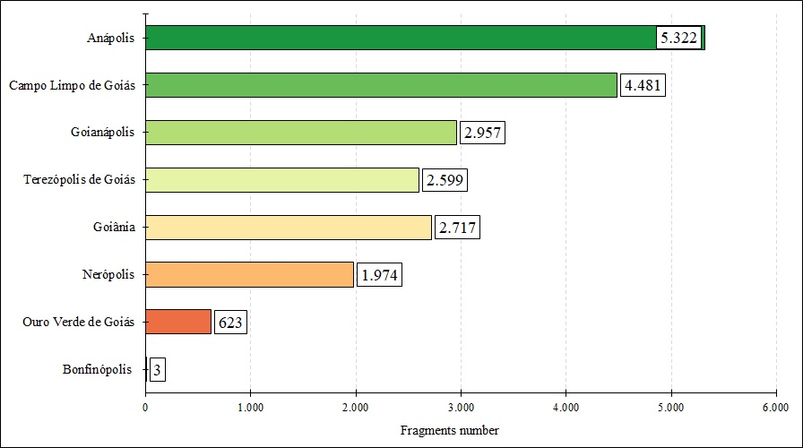

**MEAN PATCH SIZE (MPS):** This metric expresses the mean size of the fragments/patches of the tamatic class at the landscape scale of a given spatial area.

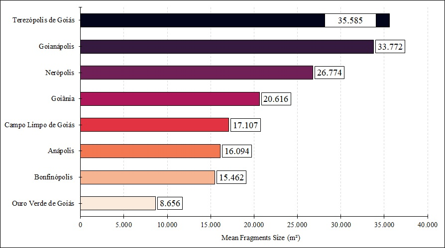

**COMPACTNESS (CI):** This index describes the compactness of a given fragment/patch, taking into account the Perimeter-Area ratio. The index is (0-1) with the less compact areas taking on values closer to 0.

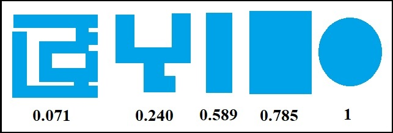

[^1]: PhD student in Geography, Institute of Socio-Environmental Studies, Federal University of Goiás